# real states prize pridiction

### REAL STATE PRICE PRIDICTER

```python
import pandas as pd
```

```python
housing = pd.read_csv("data.csv")
```

```python
housing.head()
```

|  | CRIM | ZN | INDUS | CHAS | NOX | RM | AGE | DIS | RAD | TAX | PTRATIO | B | LSTAT | MEDV |
| --- | --- | --- | --- | --- | --- | --- | --- | --- | --- | --- | --- | --- | --- | --- |
| 0 | 0.00632 | 18.0 | 2.31 | 0 | 0.538 | 6.575 | 65.2 | 4.0900 | 1 | 296 | 15.3 | 396.90 | 4.98 | 24.0 |
| 1 | 0.02731 | 0.0 | 7.07 | 0 | 0.469 | 6.421 | 78.9 | 4.9671 | 2 | 242 | 17.8 | 396.90 | 9.14 | 21.6 |
| 2 | 0.02729 | 0.0 | 7.07 | 0 | 0.469 | 7.185 | 61.1 | 4.9671 | 2 | 242 | 17.8 | 392.83 | 4.03 | 34.7 |
| 3 | 0.03237 | 0.0 | 2.18 | 0 | 0.458 | 6.998 | 45.8 | 6.0622 | 3 | 222 | 18.7 | 394.63 | 2.94 | 33.4 |
| 4 | 0.06905 | 0.0 | 2.18 | 0 | 0.458 | 7.147 | 54.2 | 6.0622 | 3 | 222 | 18.7 | 396.90 | 5.33 | 36.2 |

```python
housing.info()
```

```
<class 'pandas.core.frame.DataFrame'>
RangeIndex: 506 entries, 0 to 505
Data columns (total 14 columns):
 #   Column   Non-Null Count  Dtype
---  ------   --------------  -----
 0   CRIM     506 non-null    float64
 1   ZN       506 non-null    float64
 2   INDUS    506 non-null    float64
 3   CHAS     506 non-null    int64
 4   NOX      506 non-null    float64
 5   RM       501 non-null    float64
 6   AGE      506 non-null    float64
 7   DIS      506 non-null    float64
 8   RAD      506 non-null    int64
 9   TAX      506 non-null    int64
 10  PTRATIO  506 non-null    float64
 11  B        506 non-null    float64
 12  LSTAT    506 non-null    float64
 13  MEDV     506 non-null    float64
dtypes: float64(11), int64(3)
memory usage: 55.5 KB
```

```python
housing.describe()
```

|  | CRIM | ZN | INDUS | CHAS | NOX | RM | AGE | DIS | RAD | TAX | PTRATIO | B | LSTAT | MEDV |
| --- | --- | --- | --- | --- | --- | --- | --- | --- | --- | --- | --- | --- | --- | --- |
| count | 506.000000 | 506.000000 | 506.000000 | 506.000000 | 506.000000 | 501.000000 | 506.000000 | 506.000000 | 506.000000 | 506.000000 | 506.000000 | 506.000000 | 506.000000 | 506.000000 |
| mean | 3.613524 | 11.363636 | 11.136779 | 0.069170 | 0.554695 | 6.287096 | 68.574901 | 3.795043 | 9.549407 | 408.237154 | 18.455534 | 356.674032 | 12.653063 | 22.532806 |
| std | 8.601545 | 23.322453 | 6.860353 | 0.253994 | 0.115878 | 0.705510 | 28.148861 | 2.105710 | 8.707259 | 168.537116 | 2.164946 | 91.294864 | 7.141062 | 9.197104 |
| min | 0.006320 | 0.000000 | 0.460000 | 0.000000 | 0.385000 | 3.561000 | 2.900000 | 1.129600 | 1.000000 | 187.000000 | 12.600000 | 0.320000 | 1.730000 | 5.000000 |
| 25% | 0.082045 | 0.000000 | 5.190000 | 0.000000 | 0.449000 | 5.885000 | 45.025000 | 2.100175 | 4.000000 | 279.000000 | 17.400000 | 375.377500 | 6.950000 | 17.025000 |
| 50% | 0.256510 | 0.000000 | 9.690000 | 0.000000 | 0.538000 | 6.209000 | 77.500000 | 3.207450 | 5.000000 | 330.000000 | 19.050000 | 391.440000 | 11.360000 | 21.200000 |
| 75% | 3.677083 | 12.500000 | 18.100000 | 0.000000 | 0.624000 | 6.629000 | 94.075000 | 5.188425 | 24.000000 | 666.000000 | 20.200000 | 396.225000 | 16.955000 | 25.000000 |
| max | 88.976200 | 100.000000 | 27.740000 | 1.000000 | 0.871000 | 8.780000 | 100.000000 | 12.126500 | 24.000000 | 711.000000 | 22.000000 | 396.900000 | 37.970000 | 50.000000 |

```python
%matplotlib inline
```

```
array([[<AxesSubplot:title={'center':'CRIM'}>,
        <AxesSubplot:title={'center':'ZN'}>,
        <AxesSubplot:title={'center':'INDUS'}>,
        <AxesSubplot:title={'center':'CHAS'}>],
       [<AxesSubplot:title={'center':'NOX'}>,
        <AxesSubplot:title={'center':'RM'}>,
        <AxesSubplot:title={'center':'AGE'}>,
        <AxesSubplot:title={'center':'DIS'}>],
       [<AxesSubplot:title={'center':'RAD'}>,
        <AxesSubplot:title={'center':'TAX'}>,
        <AxesSubplot:title={'center':'PTRATIO'}>,
        <AxesSubplot:title={'center':'B'}>],
       [<AxesSubplot:title={'center':'LSTAT'}>,
        <AxesSubplot:title={'center':'MEDV'}>, <AxesSubplot:>,
        <AxesSubplot:>]], dtype=object)
```

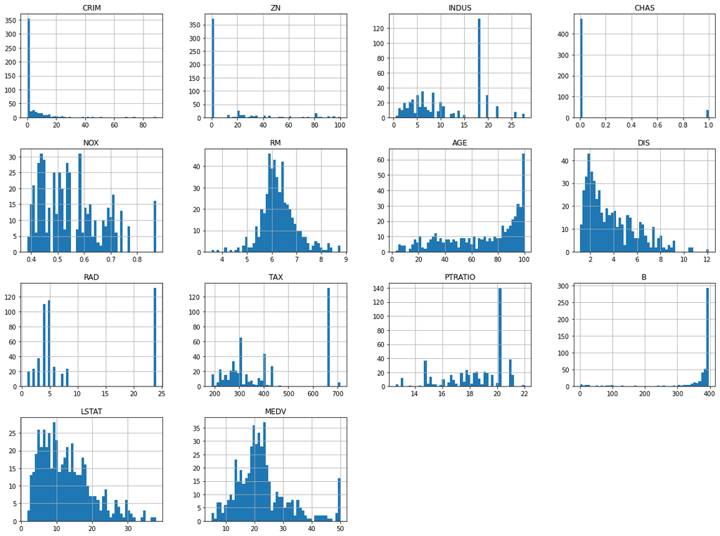

```python
#for ploting histogram
import matplotlib.pyplot as plt
housing.hist(bins=50 , figsize=(20,15)) #we have to write "plt.show" in the end to see the graphs if we are coading any ID (PYCHARM ETC.)
```

## TRAIN-TEST SPLITING

```python
#for learning purpose


# import numpy as np

# def split_train_test(data, test_ratio):
#     np.random.seed(42)#if dont use the "seed" then random fun. will give diff. test,train data everytime we run it  due to which some test data will be seen by algo before testing which is not good .
#     shuffled = np.random.permutation(len(data))
#     print(shuffled)
#     test_set_size = int(len(data)*test_ratio)
#     test_indices = shuffled[:test_set_size]
#     train_indices = shuffled[test_set_size:]
#     return data.iloc[train_indices], data.iloc[test_indices]
```

```python
#  train_set, test_set = split_train_test(housing, 0.2)
```

```python
# print(f"rows in train set: {len(train_set)} \nrows in test set: {len(test_set)}\n")
```

```python
from sklearn.model_selection import train_test_split
train_set, test_set = train_test_split(housing,test_size= 0.2,random_state=42)
print(f"rows in train set: {len(train_set)} \nrows in test set: {len(test_set)}\n")
```

```
rows in train set: 404
rows in test set: 102
```

```python
#Stratified Shuffing Split = it insure that model should get every type of data so that it can train accordingly(exam. =  CHAS ki value 1 bhi hosakti he ye to tumne batya hi nahi training k time paar)
```

```python
from sklearn.model_selection import StratifiedShuffleSplit
split= StratifiedShuffleSplit(n_splits= 1, test_size= 0.2, random_state= 42)
for train_index, test_index in split.split(housing ,housing["CHAS"]):
    strat_train_set = housing.loc[train_index]
    strat_test_set = housing.loc[test_index]
```

```python
 strat_train_set["CHAS"].value_counts()
```

```
0    376
1     28
Name: CHAS, dtype: int64
```

```python
 strat_test_set["CHAS"].value_counts()
```

```
0    95
1     7
Name: CHAS, dtype: int64
```

```python
#95/7 = 376/28
```

```python
housing = strat_train_set.copy()#ye mene imupter k baad kiya
#while working with big data in ML iss step k baad ik copy lele
```

# looking for correlation

```python
corr_matrix = housing.corr()
corr_matrix["MEDV"].sort_values(ascending=False)
```

```
MEDV       1.000000
RM         0.679933
B          0.361761
ZN         0.339741
DIS        0.240451
CHAS       0.205066
AGE       -0.364596
RAD       -0.374693
CRIM      -0.393715
NOX       -0.422873
TAX       -0.456657
INDUS     -0.473516
PTRATIO   -0.493534
LSTAT     -0.740494
Name: MEDV, dtype: float64
```

```python
#pearson correlation coff = dependence of one thing on dec. , inc. of other thing
# (kisi chij ko  agar inc. ya dec. karoge to dosri chij inc hogi ya dec.)
# strong + correlation =1 ( ye inc. to wo bhi inc. same rate se)
# strong - correlation =-1 ( ye inc. to wo dec. same rate se)
```

```
array([[<AxesSubplot:xlabel='RM', ylabel='RM'>,
        <AxesSubplot:xlabel='MEDV', ylabel='RM'>,
        <AxesSubplot:xlabel='ZN', ylabel='RM'>,
        <AxesSubplot:xlabel='LSTAT', ylabel='RM'>],
       [<AxesSubplot:xlabel='RM', ylabel='MEDV'>,
        <AxesSubplot:xlabel='MEDV', ylabel='MEDV'>,
        <AxesSubplot:xlabel='ZN', ylabel='MEDV'>,
        <AxesSubplot:xlabel='LSTAT', ylabel='MEDV'>],
       [<AxesSubplot:xlabel='RM', ylabel='ZN'>,
        <AxesSubplot:xlabel='MEDV', ylabel='ZN'>,
        <AxesSubplot:xlabel='ZN', ylabel='ZN'>,
        <AxesSubplot:xlabel='LSTAT', ylabel='ZN'>],
       [<AxesSubplot:xlabel='RM', ylabel='LSTAT'>,
        <AxesSubplot:xlabel='MEDV', ylabel='LSTAT'>,
        <AxesSubplot:xlabel='ZN', ylabel='LSTAT'>,
        <AxesSubplot:xlabel='LSTAT', ylabel='LSTAT'>]], dtype=object)
```

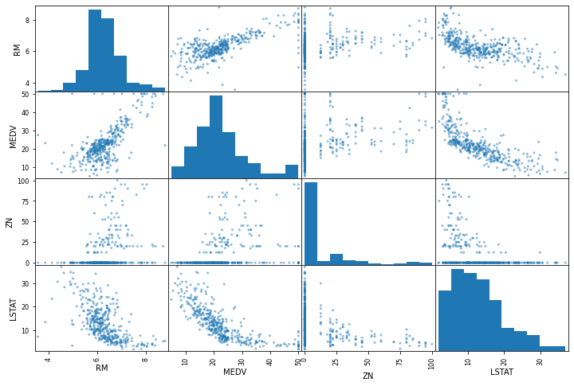

```python
from pandas.plotting import scatter_matrix
attributes = ["RM","MEDV","ZN","LSTAT"]
scatter_matrix(housing[attributes], figsize = (12,8))
```

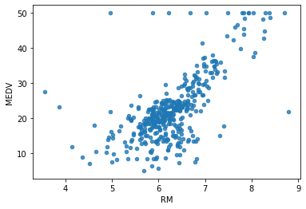

```python
housing.plot(kind = "scatter", x="RM", y="MEDV" , alpha=0.8)
```

```python
#hum outlaiers ko hata sakte he (outlers matlab ju point bahar wale he)
```

# trying out attributes combination

```python
#we can use two attributes and create new one , this can help in improving training module
```

```python
housing["TAXRM"]= housing["TAX"]/housing["RM"]
```

```python
housing["TAXRM"]
```

```
254     51.571709
348     42.200452
476    102.714374
321     45.012547
326     45.468948
          ...
155     65.507152
423    109.126659
98      35.294118
455    102.068966
216     46.875000
Name: TAXRM, Length: 404, dtype: float64
```

```python
housing.head()
```

|  | CRIM | ZN | INDUS | CHAS | NOX | RM | AGE | DIS | RAD | TAX | PTRATIO | B | LSTAT | MEDV | TAXRM |
| --- | --- | --- | --- | --- | --- | --- | --- | --- | --- | --- | --- | --- | --- | --- | --- |
| 254 | 0.04819 | 80.0 | 3.64 | 0 | 0.392 | 6.108 | 32.0 | 9.2203 | 1 | 315 | 16.4 | 392.89 | 6.57 | 21.9 | 51.571709 |
| 348 | 0.01501 | 80.0 | 2.01 | 0 | 0.435 | 6.635 | 29.7 | 8.3440 | 4 | 280 | 17.0 | 390.94 | 5.99 | 24.5 | 42.200452 |
| 476 | 4.87141 | 0.0 | 18.10 | 0 | 0.614 | 6.484 | 93.6 | 2.3053 | 24 | 666 | 20.2 | 396.21 | 18.68 | 16.7 | 102.714374 |
| 321 | 0.18159 | 0.0 | 7.38 | 0 | 0.493 | 6.376 | 54.3 | 4.5404 | 5 | 287 | 19.6 | 396.90 | 6.87 | 23.1 | 45.012547 |
| 326 | 0.30347 | 0.0 | 7.38 | 0 | 0.493 | 6.312 | 28.9 | 5.4159 | 5 | 287 | 19.6 | 396.90 | 6.15 | 23.0 | 45.468948 |

```python
corr_matrix = housing.corr()
corr_matrix["MEDV"].sort_values(ascending=False)
```

```
MEDV       1.000000
RM         0.679933
B          0.361761
ZN         0.339741
DIS        0.240451
CHAS       0.205066
AGE       -0.364596
RAD       -0.374693
CRIM      -0.393715
NOX       -0.422873
TAX       -0.456657
INDUS     -0.473516
PTRATIO   -0.493534
TAXRM     -0.526094
LSTAT     -0.740494
Name: MEDV, dtype: float64
```

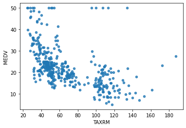

```python
housing.plot(kind = "scatter", x="TAXRM", y="MEDV" , alpha=0.8)
```

```python
#ye mene selecting ml k time paar banya tha
housing = strat_train_set.drop('MEDV', axis =1)
housing_labels = strat_train_set["MEDV"].copy()
```

# missing attributes

```python
#to take care of missing attributes ,  you have three option:
#  1.get rid of the missing data point
#  2.get rid of the whole attributes
#  3.set the value to same value(0, mean or medium)
```

```python
#1agar ik do missing data hute he to hata dete he agar jayda missing he to nahi
#2agar correltaion 0 k near huta to hata dete but "RM" nahi he 0 k near
#
```

```python
#1 execution
a=housing.dropna(subset=["RM"]).shape
```

```python
#2 execution
housing.drop("RM", axis=1).shape
#there is no RM coloumn and also note that original housing dataframe will remain unchanged
```

```
(404, 12)
```

```python
#3 execution  compute median
median = housing["RM"].median()
```

```python
median
```

```
6.2135
```

```python
#3
housing["RM"].fillna(median)
# note that original housing dataframe will remain unchanged
```

```
254    6.108
348    6.635
476    6.484
321    6.376
326    6.312
       ...
155    6.152
423    6.103
98     7.820
455    6.525
216    5.888
Name: RM, Length: 404, dtype: float64
```

# agar kahi bhi missing value hogi data set me ya fir input me waha ye median

# bhar dena (niche)

```python
housing.describe()#before we started filling missing attributes
```

|  | CRIM | ZN | INDUS | CHAS | NOX | RM | AGE | DIS | RAD | TAX | PTRATIO | B | LSTAT |
| --- | --- | --- | --- | --- | --- | --- | --- | --- | --- | --- | --- | --- | --- |
| count | 404.000000 | 404.000000 | 404.000000 | 404.000000 | 404.000000 | 400.000000 | 404.000000 | 404.000000 | 404.000000 | 404.000000 | 404.000000 | 404.000000 | 404.000000 |
| mean | 3.602814 | 10.836634 | 11.344950 | 0.069307 | 0.558064 | 6.282595 | 69.039851 | 3.746210 | 9.735149 | 412.341584 | 18.473267 | 353.392822 | 12.791609 |
| std | 8.099383 | 22.150636 | 6.877817 | 0.254290 | 0.116875 | 0.715845 | 28.258248 | 2.099057 | 8.731259 | 168.672623 | 2.129243 | 96.069235 | 7.235740 |
| min | 0.006320 | 0.000000 | 0.740000 | 0.000000 | 0.389000 | 3.561000 | 2.900000 | 1.129600 | 1.000000 | 187.000000 | 13.000000 | 0.320000 | 1.730000 |
| 25% | 0.086962 | 0.000000 | 5.190000 | 0.000000 | 0.453000 | 5.878750 | 44.850000 | 2.035975 | 4.000000 | 284.000000 | 17.400000 | 374.617500 | 6.847500 |
| 50% | 0.286735 | 0.000000 | 9.900000 | 0.000000 | 0.538000 | 6.213500 | 78.200000 | 3.122200 | 5.000000 | 337.000000 | 19.000000 | 390.955000 | 11.570000 |
| 75% | 3.731923 | 12.500000 | 18.100000 | 0.000000 | 0.631000 | 6.632000 | 94.100000 | 5.100400 | 24.000000 | 666.000000 | 20.200000 | 395.630000 | 17.102500 |
| max | 73.534100 | 100.000000 | 27.740000 | 1.000000 | 0.871000 | 8.780000 | 100.000000 | 12.126500 | 24.000000 | 711.000000 | 22.000000 | 396.900000 | 36.980000 |

```python
from sklearn.impute import SimpleImputer
imputer = SimpleImputer(strategy="median")
imputer.fit(housing)
```

```
SimpleImputer(strategy='median')
```

```python
imputer.statistics_
```

```
array([2.86735e-01, 0.00000e+00, 9.90000e+00, 0.00000e+00, 5.38000e-01,
       6.21350e+00, 7.82000e+01, 3.12220e+00, 5.00000e+00, 3.37000e+02,
       1.90000e+01, 3.90955e+02, 1.15700e+01])
```

```python
x=imputer.transform(housing)
```

```python
housing_tr = pd.DataFrame(x,columns=housing.columns)
```

```python
housing_tr.describe()
```

|  | CRIM | ZN | INDUS | CHAS | NOX | RM | AGE | DIS | RAD | TAX | PTRATIO | B | LSTAT |
| --- | --- | --- | --- | --- | --- | --- | --- | --- | --- | --- | --- | --- | --- |
| count | 404.000000 | 404.000000 | 404.000000 | 404.000000 | 404.000000 | 404.000000 | 404.000000 | 404.000000 | 404.000000 | 404.000000 | 404.000000 | 404.000000 | 404.000000 |
| mean | 3.602814 | 10.836634 | 11.344950 | 0.069307 | 0.558064 | 6.281911 | 69.039851 | 3.746210 | 9.735149 | 412.341584 | 18.473267 | 353.392822 | 12.791609 |
| std | 8.099383 | 22.150636 | 6.877817 | 0.254290 | 0.116875 | 0.712316 | 28.258248 | 2.099057 | 8.731259 | 168.672623 | 2.129243 | 96.069235 | 7.235740 |
| min | 0.006320 | 0.000000 | 0.740000 | 0.000000 | 0.389000 | 3.561000 | 2.900000 | 1.129600 | 1.000000 | 187.000000 | 13.000000 | 0.320000 | 1.730000 |
| 25% | 0.086962 | 0.000000 | 5.190000 | 0.000000 | 0.453000 | 5.879750 | 44.850000 | 2.035975 | 4.000000 | 284.000000 | 17.400000 | 374.617500 | 6.847500 |
| 50% | 0.286735 | 0.000000 | 9.900000 | 0.000000 | 0.538000 | 6.213500 | 78.200000 | 3.122200 | 5.000000 | 337.000000 | 19.000000 | 390.955000 | 11.570000 |
| 75% | 3.731923 | 12.500000 | 18.100000 | 0.000000 | 0.631000 | 6.630250 | 94.100000 | 5.100400 | 24.000000 | 666.000000 | 20.200000 | 395.630000 | 17.102500 |
| max | 73.534100 | 100.000000 | 27.740000 | 1.000000 | 0.871000 | 8.780000 | 100.000000 | 12.126500 | 24.000000 | 711.000000 | 22.000000 | 396.900000 | 36.980000 |

# scikit-learn design

primarly, three types of objects

1. estimators - It estimates some parameter based on a dataset. Eg. imputer . It has fit method and transform method. Fit method - fits the datasets and calculates internal parameters. it has some hyperparameters like strategy
2. transformers - transform method takes input an returns output based on the learning from fit(). it has a convenience function called fit_trandform() which fits and then transform
3. predictors - Linerregression model is an example of predictor. fit() and predict() are two common functions. it also gives score function which will evaluate the predictions

# Feature Scaling

primarly , two types of feature scaling method:

1. Min-Max scaling (Normalisation) (value-min)/(max-min) sklearn provide a class called MinMaxScaler for this
2. Stadardization (Value - Mean)/std Sklearn provides a class called StandardScaler for this

# creating pipeline

```python
from sklearn.pipeline import Pipeline
from sklearn.preprocessing import StandardScaler
my_pipeline = Pipeline([
    ("imputer", SimpleImputer(strategy='median')),
    #......add as many as you want in your pipeline
    ('std_scaler', StandardScaler())
])
```

```python
housing_num_tr = my_pipeline.fit_transform(housing)
```

```python
housing_num_tr
```

```
array([[-0.43942006,  3.12628155, -1.12165014, ..., -0.97491834,
         0.41164221, -0.86091034],
       [-0.44352175,  3.12628155, -1.35893781, ..., -0.69277865,
         0.39131918, -0.94116739],
       [ 0.15682292, -0.4898311 ,  0.98336806, ...,  0.81196637,
         0.44624347,  0.81480158],
       ...,
       [-0.43525657, -0.4898311 , -1.23083158, ..., -0.22254583,
         0.41831233, -1.27603303],
       [ 0.14210728, -0.4898311 ,  0.98336806, ...,  0.81196637,
        -3.15239177,  0.73869575],
       [-0.43974024, -0.4898311 ,  0.37049623, ..., -0.97491834,
         0.41070422,  0.09940681]])
```

```python
housing_num_tr.shape
```

```
(404, 13)
```

yaha hum pipeline alag bana rahe he but real world problem me pipeline starting se hi banana huta he

# selecting a desired model for Real Estates

```python
from sklearn.linear_model import LinearRegression
from sklearn.tree import DecisionTreeRegressor
from sklearn.ensemble import RandomForestRegressor
# model = LinearRegression() # error bhut jayda tha , cross validation k baad bhi
model = DecisionTreeRegressor() #overfitting karliya , isiliye cross validation kardiya
# model= RandomForestRegressor()
model.fit(housing_num_tr,housing_labels)
```

```
DecisionTreeRegressor()
```

```python
some_data = housing.iloc[:5]
```

```python
some_labels = housing_labels.iloc[:5]
```

```python
prepared_data = my_pipeline.transform(some_data)
```

```python
model.predict(prepared_data)
```

```
array([21.9, 24.5, 16.7, 23.1, 23. ])
```

```python
some_labels
```

```
254    21.9
348    24.5
476    16.7
321    23.1
326    23.0
Name: MEDV, dtype: float64
```

# evaluating the model

```python
import numpy as np
from sklearn.metrics import mean_squared_error
housing_prediction = model.predict(housing_num_tr)
mse = mean_squared_error (housing_labels,housing_prediction )
rmse= np.sqrt(mse)
```

```python
mse
```

```
0.0
```

# using better evaluation technique - cross validation

```python
from sklearn.model_selection import cross_val_score
scores =cross_val_score(model ,housing_num_tr,housing_labels , scoring= "neg_mean_squared_error" )
rmse_score =np.sqrt(-scores)
```

```python
rmse_score
```

```
array([5.01012555, 4.22365473, 5.19992877, 5.27708767, 3.54282726])
```

```python
def print_scores(scores):
    print("scores", scores)
    print("mean",scores.mean())
    print("standard devation", scores.std())
```

```python
print_scores(rmse_score)
```

```
scores [5.01012555 4.22365473 5.19992877 5.27708767 3.54282726]
mean 4.650724797397023
standard devation 0.668273919673598
```

quiz:convert this notbook into python file and run the pipeline using visual studio code

# saving the model

```python
from joblib import dump,load
dump(model, 'Dragon.joblib')
```

```
['Dragon.joblib']
```

# testing the model on test data

```python
x_test = strat_test_set.drop('MEDV',axis=1)
y_test = strat_test_set['MEDV'].copy()
x_test_prepared = my_pipeline.transform(x_test)
final_prediction = model.predict(x_test_prepared)
final_mse = mean_squared_error(y_test ,final_prediction)
final_rmse = np.sqrt(final_mse)
# print(final_prediction ,list(y_test) )
```

```python
final_rmse
```

```
4.1374189169236475
```

```python
prepared_data[0]
```

```
array([-0.43942006,  3.12628155, -1.12165014, -0.27288841, -1.42262747,
       -0.2444511 , -1.31238772,  2.61111401, -1.0016859 , -0.5778192 ,
       -0.97491834,  0.41164221, -0.86091034])
```

# using the module

```python
from joblib import dump,load
import numpy as np
model= load( 'Dragon.joblib')

features = np.array([[-0.43942006,  3.12628155, -1.12165014, -0.27288841, -1.42262747,
       -0.2444511 , -1.31238772,  2.61111401, -1.0016859 , -0.5778192 ,
       -0.97491834,  0.41164221, -0.86091034]])
model.predict(features)
```

```
array([21.9])
```

kai baar package update hojate he isiliye warning aate ge , same with sklearn to error ko read karo , google search karo